# Module 4.1 - Interoperability Standards - WMS, KML, and XML

### Outline

- Extensible Markup Language - XML
  - Definition of a markup language
  - Requirements
  - Extensible ???
- KML - AKA Keyhole Markup Language
  - An XML Document Format
  - Combined representation of spatial data and time
- OGC Web Map Services (WMS)
  - Requests and Results
  - GetCapabilities, GetMap, GetFeatureInfo
- Integration of WMS into KML

## Extensible Markup Language - XML

### XML Background

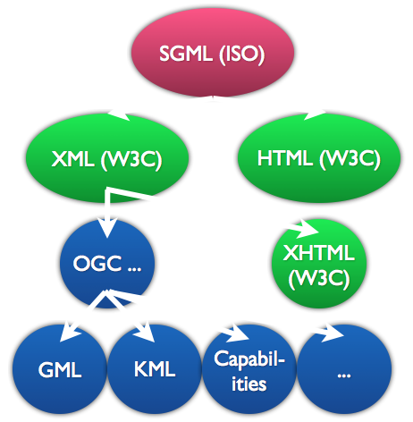

- Defined as a markup language profile of Standard Generalized Markup Language (SGML - ISO 8879:1986)
- XML 1.0 released as a W3C Recommendation in 1998
  - currently in 5th edition, released in 2008
  - version 1.1 released in 2004, but not broadly used
  - XML 1.0 (5th ed.) [Recommendation](http://www.w3.org/TR/2008/REC-xml-20081126/)

### XML Design Goals

- XML shall be straightforwardly usable over the Internet.
- XML shall support a wide variety of applications.
- XML shall be compatible with SGML.
- It shall be easy to write programs which process XML documents.
- The number of optional features in XML is to be kept to the absolute minimum, ideally zero.
- XML documents should be human-legible and reasonably clear.
- The XML design should be prepared quickly.
- The design of XML shall be formal and concise.
- XML documents shall be easy to create.
- Terseness in XML markup is of minimal importance.

From XML 1.0 (5th ed.) [Recommendation](http://www.w3.org/TR/2008/REC-xml-20081126/)

### XML Structure - Well Formed / Valid

- Well Formed XML - a document that conforms to the structural definition of XML. Either well-formed, or not XML
- Valid XML - a document that is both well-formed and conforms to a specific content structure defined by
  - A Document Type Definition (DTD) - the original XML specification for the definition of the content of a specific XML document
  - A Schema document - defined in a variety of languages (e.g. W3C Schema, RELAX NG, Schematron, ISO DSDL, etc.)

[XML Wikipedia Article](http://en.wikipedia.org/wiki/XML)

### Simple XML Document

```xml
<?xml version="1.0" encoding="ISO-8859-1"?>
<!-- Edited by XMLSpy® -->
<note>
    <to>Tove</to>
    <from>Jani</from>
    <heading>Reminder</heading>
    <body type="instruction" >Don't forget me this weekend!</body>
</note>
```

XML Source (modified from original): [w3schools](http://www.w3schools.com/XML/note.xml)

### Simple XML Document - Prolog

```xml
<?xml version="1.0" encoding="ISO-8859-1"?>
<!-- Edited by XMLSpy® -->
```

Includes XML Declaration and Comment

### Simple XML Document - Elements

```xml
<note>
    <to>Tove</to>
    <from>Jani</from>
    <heading>Reminder</heading>
    <body type="instruction" >Don't forget me this weekend!</body>
</note>
```

Define blocks of content

### Simple XML Document - Root Element

```xml
<note>
    ...
    ...
    ...
    ...
</note>
```

- Required
- There is only one
- It must be a pair of opening and closing tags

### Simple XML Document - Content Elements

```xml
    <to>Tove</to>
    <from>Jani</from>
    <heading>Reminder</heading>
    <body type="instruction" >Don't forget me this weekend!</body>
```

- Contain all other document content
- May be paired opening and closing tags, *or*
- May be self-closing with a terminal "/" in the element, e.g. `<br />`

### Simple XML Document - Attributes

```xml
    <body type="instruction" >Don't forget me this weekend!</body>
```

Define additional information about elements as *name*=*value* pairs.

### Simple XML Document - Element Content

```xml
    <body type="instruction" >Don't forget me this weekend!</body>
```

The material contained between the opening and closing tags of an *Element*.

### Simple XML Document - Valid?

```xml
<?xml version="1.0" encoding="ISO-8859-1"?>
<!-- Edited by XMLSpy® -->
<note>
    <to>Tove</to>
    <from>Jani</from>
    <heading>Reminder</heading>
    <body type="instruction" >Don't forget me this weekend!</body>
</note>
```

Why is this XML *well-formed* but not *valid*?

*There is no DTD or Schema defined for the document against which it can be validated*